# Discriminant_Function_Analysis

David Ledesma and Hans Bilger

4/25/2019

David Ledesma and Hans Bilger

May 2, 2019

# What is a discriminant function anaysis (DFA) used for?

> A DFA can be used to predict group membership based on discriminating continous variable. It can also give a sense of how well those groups can be differentiated by those variables.

> A DFA can be used to predict group membership based on discriminating continous variables. It can also give a sense of how well those groups can be differentiated by those variables.

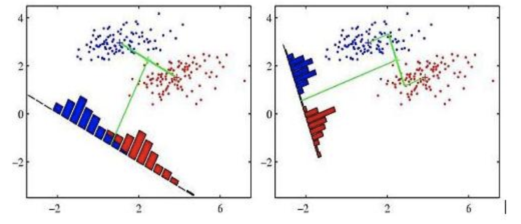

> In essence, a DFA is the reverse of a multivariate analysis of variance or MANOVA. In a MANOVA, the groups are the independent variables and the predictors are the dependent variables. For a DFA, the groups are the dependent variables while the predictors are the independent variables.

# Assumptions and limitations

> Discriminant function anaysis is similar to logistic regression and in fact both can be used to answer the same research questions. In many cases logistic regression may be preferable to a discriminant function anaysis because it has less assumptions and restrictions. However, a discriminant function anaysis may be prefered when looking at many different classifications.

> Outliers can cause problems when assessing significance and should transformed or removed. Normally distributed variables are preferred, but non-normally distributed variables will not influence model significance as long as the non-normality isn’t driven by outliers.
> 3. Independent variables must uncorrelated and have low multicollinearity.
> 4. There shouldn’t be significant heterogeneity in the variance and co-variance matricies between groups.

> > Discriminant function anaysis is similar to logistic regression. (In fact, both can be used to answer the same research questions.) In many cases, logistic regression may be preferable to a discriminant function anaysis because it has fewer assumptions and restrictions. However, a discriminant function anaysis may be prefered when the dependent variable contains more than two groups.

# How does a discriminant function anaysis work?

> The analysis creates linear combinations of predictors, so called discriminant functions. The number of functions is equal to one less than the number of groups or equal to the number of predictors, whichever is smaller. Each discriminant function maximizes the amount of discrimination between groups while also remaining non-correlated with the other discriminant functions.

> The analysis creates “discriminant functions” using the linear combinations of predictor variables. The number of functions is equal to either one less than the number of groups or the number of predictors—whichever is smaller. Each discriminant function maximizes the amount of discrimination between groups while also remaining non-correlated with the other discriminant functions. The model made from these discriminant functions can then be used to predict group membership on a new, uncharacterized sample.

# Linear discriminant analysis

```r
library(MASS) # required for the lda() function
library(tidyverse)
```

[output not shown]

[output cut: 79 more lines]

[output not shown]

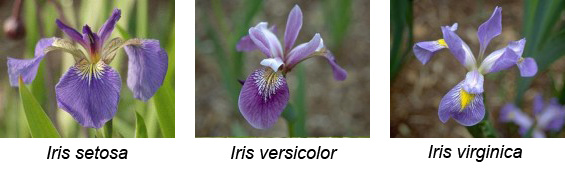

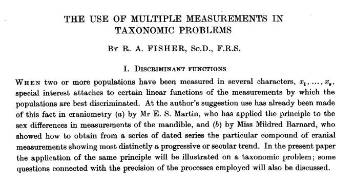

[figure not shown]

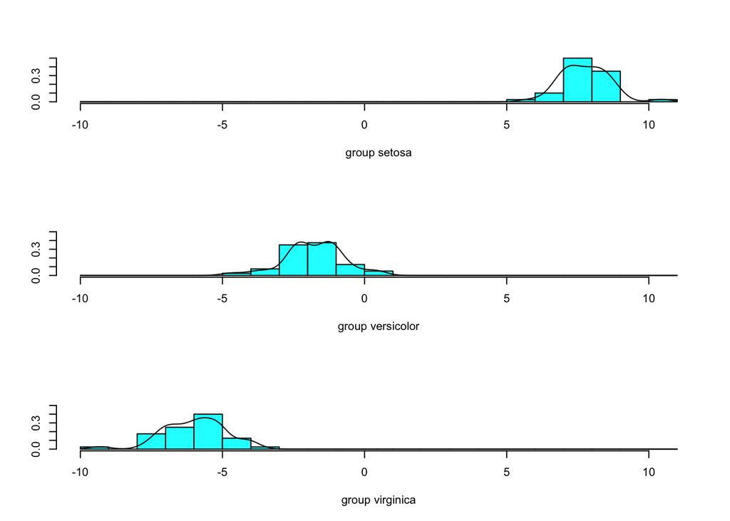

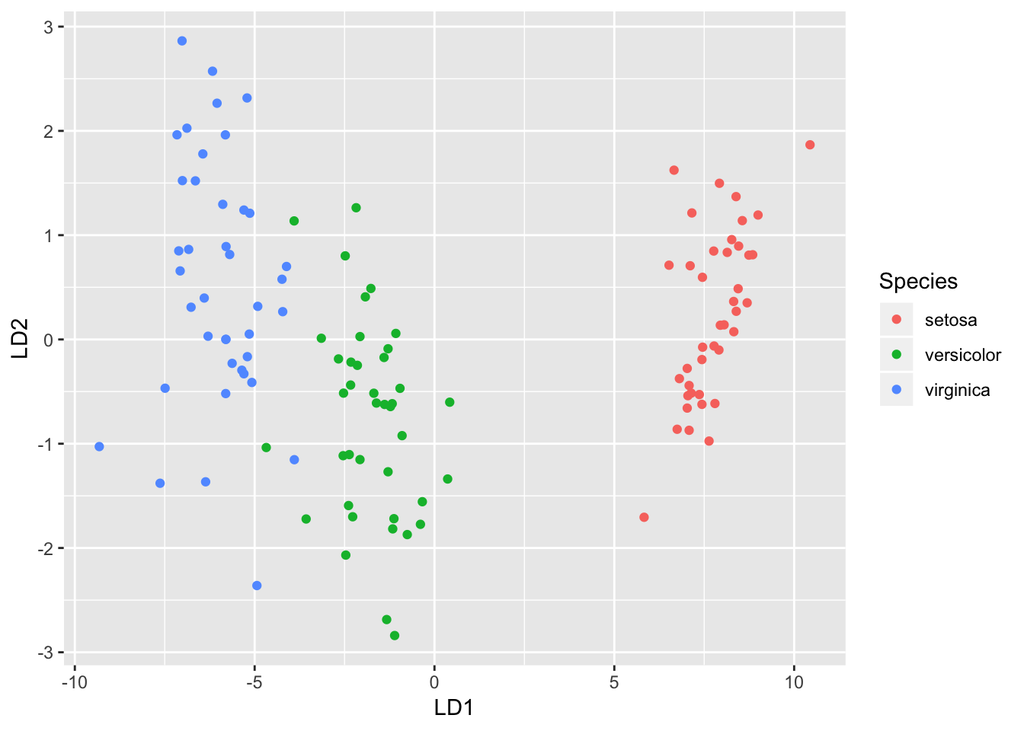

[figure not shown]

[figure not shown]

[figure not shown]

# Quadratic discriminant analysis

> Quadratic discriminant analysis is an alternative to linear discriminant analysis. This type of discriminant analysis does not assume equal variance and co-variance matricies between groups. This makes this type of analysis better for very large datasets.

```r
# Produce model
QDAmodel <- qda(Species~., data = train.transformed)
QDAmodel
```

```
## Call:
## qda(Species ~ ., data = train.transformed)
##
## Prior probabilities of groups:
##     setosa versicolor  virginica
##  0.3333333  0.3333333  0.3333333
##
## Group means:
##            Sepal.Length Sepal.Width Petal.Length Petal.Width
## setosa       -1.0120728   0.7867793   -1.2927218  -1.2496079
## versicolor    0.1174121  -0.6478157    0.2724253   0.1541511
## virginica     0.8946607  -0.1389636    1.0202965   1.0954568
```

```r
# How well does the model fit the training data?
qda.train <- predict(QDAmodel) # generate
train.transformed$qda <- qda.train$class
table(train.transformed$qda, train.transformed$Species)
```

```
##
##              setosa versicolor virginica
##   setosa         40          0         0
##   versicolor      0         38         1
##   virginica       0          2        39
```

```r
mean(qda.train$class == train.transformed$class)
```

```
## [1] NaN
```

```r
# Make predictions
predictions <- predict(QDAmodel, newdata = test.transformed)
test.transformed$qda <- predictions$class

# Model accuracy
table(test.transformed$qda, test.transformed$Species)
```

```
##
##              setosa versicolor virginica
##   setosa         10          0         0
##   versicolor      0         10         0
##   virginica       0          0        10
```

```r
mean(predictions$class == test.transformed$Species)
```

```
## [1] 1
```

```r
#  plot the quadratic discriminant functions for each variable combination
library(klaR)
partimat(Species ~ Sepal.Length + Sepal.Width + Petal.Length + Petal.Width, data=train.transformed, method="qda")
```

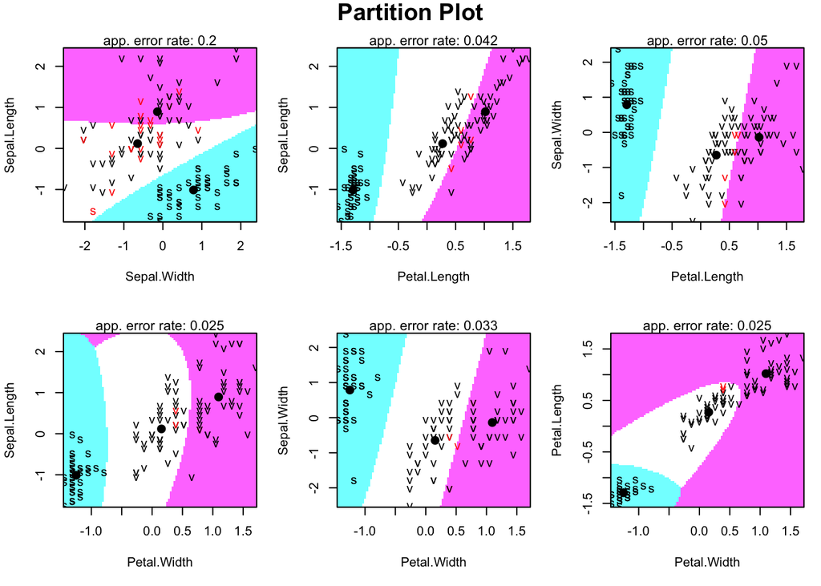

[figure not shown]